# Inference and Likelihood

Biol 607

0. Go through the faded examples in the lab. You don’t need to put the output here - just, do them! And let us know if you have any remaining questions, or you feel comfortable. Full credit!
1. Would you say you naturally gravitate towards deductive or inductive inference? Why?

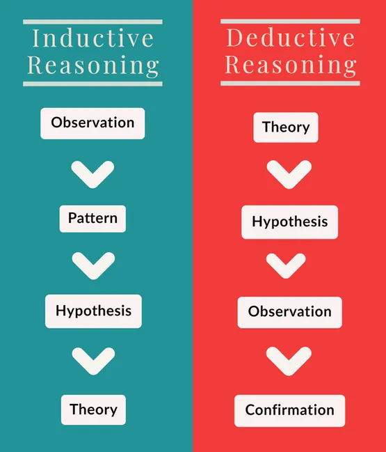

2. We talked about strictly interpreted Popperian Flasification versus Lakatos’s view of a research program this week.

2a. Do you more strongly identify with one of these paradigms? Why? +1 EC for direct quotes (if you want to do some additional reading)

**Popper**

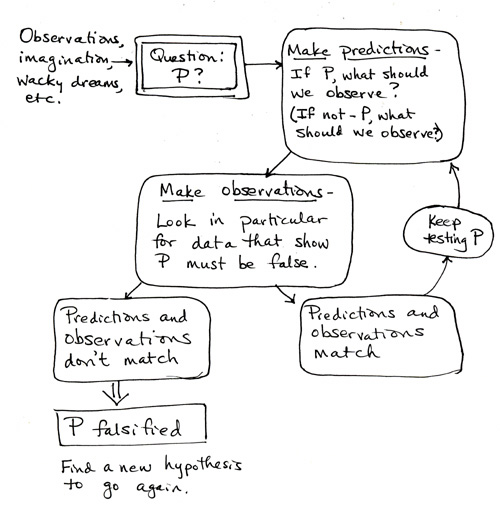

**Lakatos**

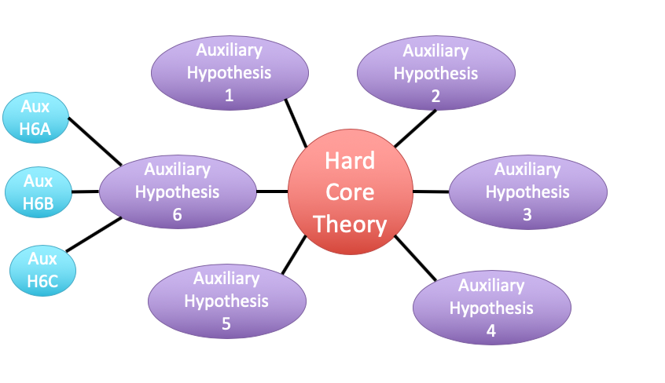

2b. How does your own research program fit into one of these paradigms?

EC x4 2c. This has been a shallow dive into Lakatos and Popper. Look them or other philosophers of science and inference up - Kuhn, Feyerabend, Musgrave, Deb Mayo, Sabra, Fillies, and others. What’s their core idea, and why do you agree or disagree?

## Puffers!

Let’s look at the [pufferfish data](http://biol607.github.io/homework/data/16q11PufferfishMimicry%20Caley%20&%20Schluter%202003.csv) with likelihood!

**3. Grid Sampling!** Based on Friday’s lab, load up the pufferfish data and use grid sampling to find the MLE of the slope, intercept and residual SD of this model. Feel free to eyeball results from an `lm()` fit to get reasonable values. Try not to do this for a grid of more than ~100K points (more if you want!). It’s ok to be coarse. Compare to lm.

**4. Surfaces!** Filter the dataset to the MLE of the SD. Plot the surface for the slope and intercept in whatever way you find most compelling. You might want to play around with zooming in to different regions, etc. Have fun!

**5. GLM!** Now, compare those results to results from glm. Show the profiles and confidence intervals from `glm()` for the slope and intercept. Also show how you validate assumptions.

**EC 6. Get Outside of GLM!** So, often, we have more complex models than the above. There are a variety of optimizers out there, and packages for accessing them. One of the best is `bbmle` by Ecologist Ben Bolker (whose dad is emeritus at UMB in computer science! Go visit him! He’s fantastic!)

Load up `'bbmle` and try out `mle2`. It’s a bit different, in that the first argument is a function that *minimizes* the log likelihood (not maximizes). The second argument is a list of start values - e.g. `list(slope = 2, intercept = 5, resid_sd = 2)`. Try and fit your model with `mle2` using start values close to the actual estimates. Look at the summary and plot the profile. Note, you might get a lot of errors because it will try impossible values of your residual SD. Also, note thatyou’ll have to rewrite your likelihood function to return the negative log likelihood (or write a wrapper that does so). A small thing

**EC 6a. Start values!** What happens if you start with start values *very* far away from the initial values. Failing here is fine. But what do you think is happening, and what does this say about the value of start values?

**EC 6b Algorithms!** By default, `mle2` uses the Nelder-Mead algorithm via the `optim` function. What happens if you add an `method` argument to “SANN” or “L-BFGS-B” (and for the later, which is bounded sampling, give it a `lower` argument for your residual value, so it’s always positive). See `?optim` for some more guidance. Do these both converge to the same value? Based on their profiles, do you trust them? (Note, Simulated annealing takes a looooong time. Go have a cuppa while the profile for that one runs).